# Lab5 Solutions

Rushal Sohal; github: rushalsohal

4/11/2020

```r
library(tidyverse)
acc <- read.csv("https://raw.githubusercontent.com/xdaiISU/ds202materials/master/hwlabs/fars2017/accident.csv", stringsAsFactors = FALSE)
pers <- read.csv("https://raw.githubusercontent.com/xdaiISU/ds202materials/master/hwlabs/fars2017/person.csv", stringsAsFactors = FALSE)
```

# Part 1

#1

```r
table(acc$DAY_WEEK)
```

```
##
##    1    2    3    4    5    6    7
## 5360 4374 4347 4314 4621 5358 5873
```

Saturday seems to have more traffic accidents than any other day. Besides, weekends overall have comparatively more accidents.

#2

```r
table(acc$HOUR)
```

```
##
##    0    1    2    3    4    5    6    7    8    9   10   11   12   13   14   15
## 1321 1177 1241  957  813 1065 1282 1162  945  929 1064 1198 1403 1480 1613 1760
##   16   17   18   19   20   21   22   23   99
## 1770 1916 2000 1880 1930 1880 1683 1516  262
```

Accidents tend to happen the most between 5pm and 9pm. Moreover, accidents are fewer in the morning between 7am and 9am.

#3

```r
acc %>%
  filter(DRUNK_DR >= 1) %>%
  summarize(n = n())
```

```
##      n
## 1 8769
```

There are 8769 accidents involving at least one drunk driver.

#Part 2

#4

```r
pertyp <- pers %>% filter(PER_TYP == 1)
head(pertyp)
```

```
##   STATE ST_CASE VE_FORMS VEH_NO PER_NO STR_VEH COUNTY DAY MONTH HOUR MINUTE
## 1     1   10001        1      1      1       0     73  19     2   23     35
## 2     1   10002        1      1      1       0     89  14     2   14     59
## 3     1   10003        3      1      1       0    101  31     1   20     31
## 4     1   10003        3      2      1       0    101  31     1   20     31
## 5     1   10003        3      3      1       0    101  31     1   20     31
## 6     1   10004        1      1      1       0     73   1     1   16     55
##   RUR_URB FUNC_SYS HARM_EV MAN_COLL SCH_BUS MAKE MAK_MOD BODY_TYP MOD_YEAR
## 1       2        1      38        0       0   20   20421       15     2004
## 2       2        1       1        0       0   37   37402       14     2005
## 3       2        1      12        1       0   82   82881       66     2007
## 4       2        1      12        1       0    2    2404       14     2003
## 5       2        1      12        1       0   84   84884       66     2015
## 6       2        4      30        0       0   30   30046        4     2014
##   TOW_VEH SPEC_USE EMER_USE ROLLOVER IMPACT1 FIRE_EXP AGE SEX PER_TYP INJ_SEV
```

[output cut: 41 more lines]

#5

```r
joined <- full_join(acc, pers)
head(joined)
```

```
##   STATE ST_CASE VE_TOTAL VE_FORMS PVH_INVL PEDS PERNOTMVIT PERMVIT PERSONS
## 1     1   10001        1        1        0    0          0       1       1
## 2     1   10002        1        1        0    0          0       1       1
## 3     1   10003        3        3        0    0          0       3       3
## 4     1   10003        3        3        0    0          0       3       3
## 5     1   10003        3        3        0    0          0       3       3
## 6     1   10004        1        1        0    0          0       1       1
##   COUNTY CITY DAY MONTH YEAR DAY_WEEK HOUR MINUTE NHS RUR_URB FUNC_SYS RD_OWNER
## 1     73  330  19     2 2017        1   23     35   1       2        1        1
## 2     89 1730  14     2 2017        3   14     59   1       2        1        1
## 3    101 2130  31     1 2017        3   20     31   1       2        1        1
## 4    101 2130  31     1 2017        3   20     31   1       2        1        1
## 5    101 2130  31     1 2017        3   20     31   1       2        1        1
## 6     73  350   1     1 2017        1   16     55   0       2        4        4
##   ROUTE        TWAY_ID       TWAY_ID2 MILEPT LATITUDE  LONGITUD SP_JUR HARM_EV
```

[output cut: 69 more lines]

#6

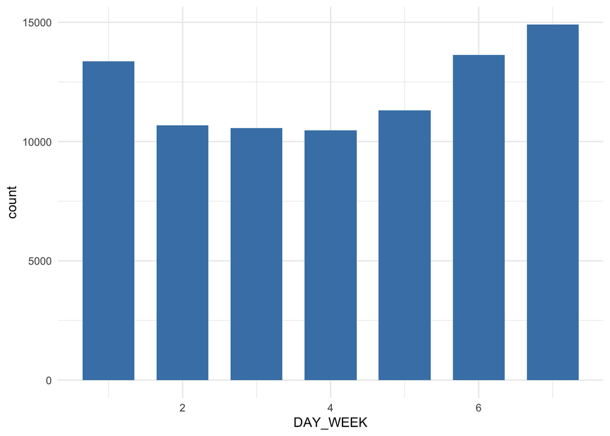

```r
day_week <- table(joined$DAY_WEEK)
ggplot(joined, aes(DAY_WEEK))+
  geom_bar(stat="count", width=0.7, fill="steelblue")+
  theme_minimal()
```

We can see that more accidents tend to happen over the weekend as more people are out drinking on weekends.

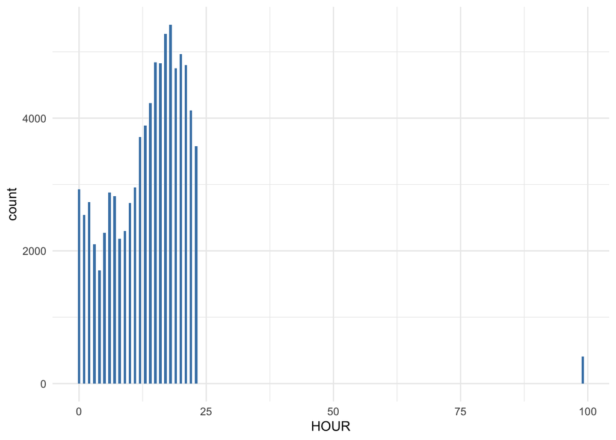

```r
hour <- table(joined$HOUR)
ggplot(joined, aes(HOUR))+
  geom_bar(stat="count", width=0.5, fill="steelblue")+
  theme_minimal()
```

We can see that most accidents happen between 5pm and 9pm.

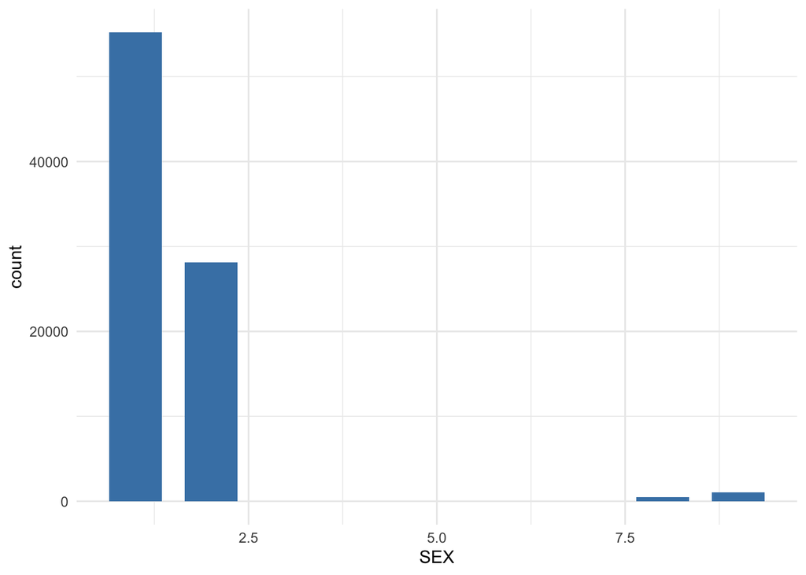

```r
sex <- table(joined$SEX)
ggplot(joined, aes(SEX))+
  geom_bar(stat="count", width=0.7, fill="steelblue")+
  theme_minimal()
```

We can see that men are in approximately double the accidents that women are in. It could be because of rash driving by men and that men in general drive more than women.

#7,8

```r
glc <- readxl::read_xlsx('FRPP GLC - United StatesFeb132020.xlsx')
glc <- glc %>%
   select('State Name', STATE = 'State Code', COUNTY = 'County Code', 'County Name') %>%
   unique()
#cleaning
glc$STATE <- as.integer(glc$STATE)
glc$COUNTY <- as.integer(glc$COUNTY)
glc$`State Name` <- tolower(glc$`State Name`)
glc$`County Name` <- tolower(glc$`County Name`)
```

```r
#joining acc and glc
choro <- acc %>%
   select(STATE, ST_CASE, COUNTY) %>%
   group_by(STATE, COUNTY) %>%
   summarize(accidents = n()) %>%
   left_join(glc, by = c('STATE', 'COUNTY'))
```

```r
#loading map data
counties <- map_data('county')
counties <- counties %>%
   mutate(`State Name` = region, `County Name` = subregion) %>%
   select(`State Name`, `County Name`, long, lat, group, order)
```

```r
#full join on all three
choro <- choro %>%
   full_join(counties, by = c('State Name', 'County Name'))
choro <- choro[order(choro$order), ]
```

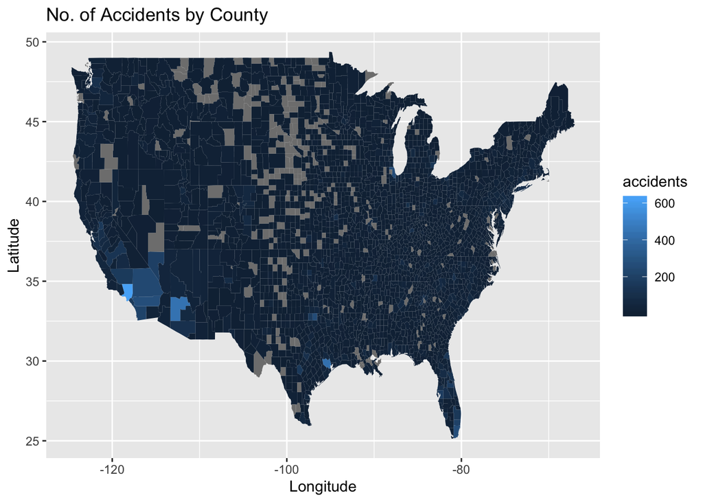

```r
#plotting the graph
ggplot(choro, aes(long, lat)) +
   geom_polygon(aes(group = group, fill = accidents)) +
   xlab('Longitude') +
   ylab('Latitude') +
   ggtitle('No. of Accidents by County')
```

Most counties have less than 200 accidents. However, some areas like parts of Texas and California have higher number of cases.

#9

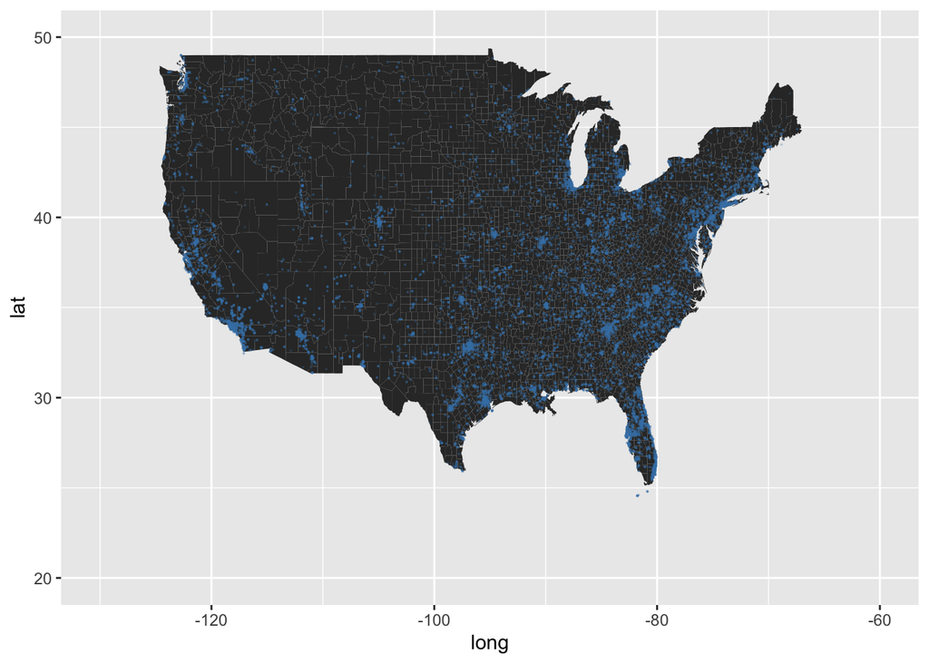

```r
ggplot(data = choro, aes(x=long, y=lat)) +
  geom_polygon(aes(group=group)) +
  geom_point(data = joined %>% filter(MONTH %in% c(1,2,12)), aes(x=LONGITUD, y=LATITUDE), color = 'steelblue', alpha = .2, size = .02) +
  xlim(c(-130, -60)) + ylim(c(20, 50))
```

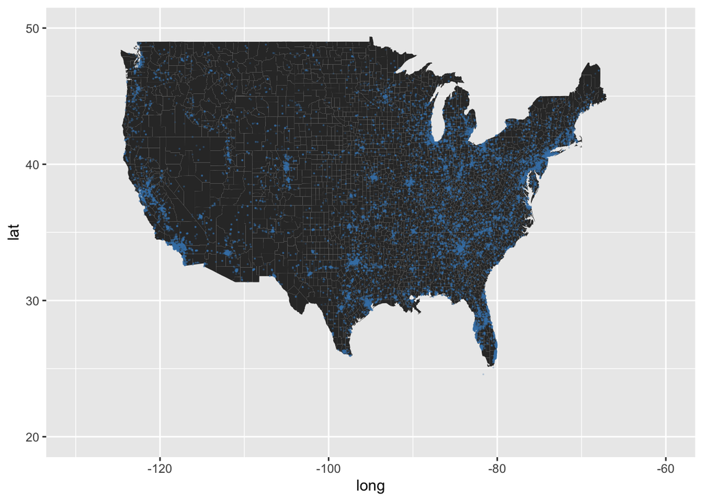

```r
ggplot(data = choro, aes(x=long, y=lat)) +
  geom_polygon(aes(group=group)) +
  geom_point(data = joined %>% filter(MONTH %in% c(6,7,8)), aes(x=LONGITUD, y=LATITUDE), color = 'steelblue', alpha = .2, size = .02) +
  xlim(c(-130, -60)) + ylim(c(20, 50))
```